# HAR Project

## Human Activity Recognition

### Problem Statement : Given a new datapoint we have to predict the Activity

## Project Description¶

- This project is to build a model that predicts the human activities such as Walking, Walking_Upstairs, Walking_Downstairs, Sitting, Standing or Laying.
- This dataset is collected from 30 persons(referred as subjects in this dataset), performing different activities with a smartphone to their waists. The data is recorded with the help of sensors (accelerometer and Gyroscope) in that smartphone.
- This experiment was video recorded to label the data manually.

### Feature names:¶

- These sensor signals are preprocessed by applying noise filters and then sampled in fixed-width windows(sliding windows) of 2.56 seconds each with 50% overlap. ie., each window has 128 readings.
- From Each window, a feature vector was obtianed by calculating variables from the time and frequency domain. In our dataset, each datapoint represents a window with different readings
- The accelertion signal was saperated into Body and Gravity acceleration signals(tBodyAcc-XYZ and tGravityAcc-XYZ) using some low pass filter with corner frequecy of 0.3Hz.
- After that, the body linear acceleration and angular velocity were derived in time to obtian jerk signals (tBodyAccJerk-XYZ and tBodyGyroJerk-XYZ).
- The magnitude of these 3-dimensional signals were calculated using the Euclidian norm. This magnitudes are represented as features with names like tBodyAccMag, tGravityAccMag, tBodyAccJerkMag, tBodyGyroMag and tBodyGyroJerkMag.
- Finally, We've got frequency domain signals from some of the available signals by applying a FFT (Fast Fourier Transform). These signals obtained were labeled with prefix 'f' just like original signals with prefix 't'. These signals are labeled as fBodyAcc-XYZ, fBodyGyroMag etc.,.
- These are the signals that we got so far. • tBodyAcc-XYZ • tGravityAcc-XYZ • tBodyAccJerk-XYZ • tBodyGyro-XYZ • tBodyGyroJerk-XYZ • tBodyAccMag • tGravityAccMag • tBodyAccJerkMag • tBodyGyroMag • tBodyGyroJerkMag • fBodyAcc-XYZ • fBodyAccJerk-XYZ • fBodyGyro-XYZ • fBodyAccMag • fBodyAccJerkMag • fBodyGyroMag • fBodyGyroJerkMag
- We can esitmate some set of variables from the above signals. ie., We will estimate the following properties on each and every signal that we recoreded so far.
  - mean(): Mean value
  - std(): Standard deviation
  - mad(): Median absolute deviation
  - max(): Largest value in array
  - min(): Smallest value in array
  - sma(): Signal magnitude area
  - energy(): Energy measure. Sum of the squares divided by the number of values. iqr(): Interquartile range
  - entropy(): Signal entropy
  - arCoeff(): Autorregresion coefficients with Burg order equal to 4
  - correlation(): correlation coefficient between two signals
  - maxInds(): index of the frequency component with largest magnitude
  - meanFreq(): Weighted average of the frequency components to obtain a mean frequency
  - skewness(): skewness of the frequency domain signal
  - kurtosis(): kurtosis of the frequency domain signal
  - bandsEnergy(): Energy of a frequency interval within the 64 bins of the FFT of each window.
    - angle(): Angle between to vectors.
- We can obtain some other vectors by taking the average of signals in a single window sample. These are used on the angle() variable '• gravityMean • tBodyAccMean • tBodyAccJerkMean • tBodyGyroMean • tBodyGyroJerkMean

### Y_Labels(Encoded): In the dataset, Y_labels are represented as numbers from 1 to 6 as their identifiers.¶

- WALKING as 1
- WALKING_UPSTAIRS as 2
- WALKING_DOWNSTAIRS as 3
- SITTING as 4
- STANDING as 5
- LAYING as 6

### Train and test data were saperated¶

- The readings from 70% of the volunteers were taken as trianing data and remaining 30% subjects recordings were taken for test data.

```python
# import packages
import numpy as np
import pandas as pd
import matplotlib.pyplot as plt
import seaborn as sns
```

## Train Data

```python
# Read the data
data_train=pd.read_csv("train.csv")
data_train.head()
```

|  | tBodyAccmeanX | tBodyAccmeanY | tBodyAccmeanZ | tBodyAccstdX | tBodyAccstdY | tBodyAccstdZ | tBodyAccmadX | tBodyAccmadY | tBodyAccmadZ | tBodyAccmaxX | ... | angletBodyAccMeangravity | angletBodyAccJerkMeangravityMean | angletBodyGyroMeangravityMean | angletBodyGyroJerkMeangravityMean | angleXgravityMean | angleYgravityMean | angleZgravityMean | subject | Activity | ActivityName |
| --- | --- | --- | --- | --- | --- | --- | --- | --- | --- | --- | --- | --- | --- | --- | --- | --- | --- | --- | --- | --- | --- |
| 0 | 0.288585 | -0.020294 | -0.132905 | -0.995279 | -0.983111 | -0.913526 | -0.995112 | -0.983185 | -0.923527 | -0.934724 | ... | -0.112754 | 0.030400 | -0.464761 | -0.018446 | -0.841247 | 0.179941 | -0.058627 | 1 | 5 | STANDING |
| 1 | 0.278419 | -0.016411 | -0.123520 | -0.998245 | -0.975300 | -0.960322 | -0.998807 | -0.974914 | -0.957686 | -0.943068 | ... | 0.053477 | -0.007435 | -0.732626 | 0.703511 | -0.844788 | 0.180289 | -0.054317 | 1 | 5 | STANDING |
| 2 | 0.279653 | -0.019467 | -0.113462 | -0.995380 | -0.967187 | -0.978944 | -0.996520 | -0.963668 | -0.977469 | -0.938692 | ... | -0.118559 | 0.177899 | 0.100699 | 0.808529 | -0.848933 | 0.180637 | -0.049118 | 1 | 5 | STANDING |
| 3 | 0.279174 | -0.026201 | -0.123283 | -0.996091 | -0.983403 | -0.990675 | -0.997099 | -0.982750 | -0.989302 | -0.938692 | ... | -0.036788 | -0.012892 | 0.640011 | -0.485366 | -0.848649 | 0.181935 | -0.047663 | 1 | 5 | STANDING |
| 4 | 0.276629 | -0.016570 | -0.115362 | -0.998139 | -0.980817 | -0.990482 | -0.998321 | -0.979672 | -0.990441 | -0.942469 | ... | 0.123320 | 0.122542 | 0.693578 | -0.615971 | -0.847865 | 0.185151 | -0.043892 | 1 | 5 | STANDING |

5 rows × 564 columns

```python
# Read the shape of data
data_train.shape
```

```
(7352, 564)
```

```python
# read columns name
data_train.columns
```

```
Index(['tBodyAccmeanX', 'tBodyAccmeanY', 'tBodyAccmeanZ', 'tBodyAccstdX',
       'tBodyAccstdY', 'tBodyAccstdZ', 'tBodyAccmadX', 'tBodyAccmadY',
       'tBodyAccmadZ', 'tBodyAccmaxX',
       ...
       'angletBodyAccMeangravity', 'angletBodyAccJerkMeangravityMean',
       'angletBodyGyroMeangravityMean', 'angletBodyGyroJerkMeangravityMean',
       'angleXgravityMean', 'angleYgravityMean', 'angleZgravityMean',
       'subject', 'Activity', 'ActivityName'],
      dtype='object', length=564)
```

```python
# information about Train data
data_train.info()
```

```
<class 'pandas.core.frame.DataFrame'>
RangeIndex: 7352 entries, 0 to 7351
Columns: 564 entries, tBodyAccmeanX to ActivityName
dtypes: float64(561), int64(2), object(1)
memory usage: 31.6+ MB
```

```python
# description of Train data
data_train.describe()
```

|  | tBodyAccmeanX | tBodyAccmeanY | tBodyAccmeanZ | tBodyAccstdX | tBodyAccstdY | tBodyAccstdZ | tBodyAccmadX | tBodyAccmadY | tBodyAccmadZ | tBodyAccmaxX | ... | fBodyBodyGyroJerkMagkurtosis | angletBodyAccMeangravity | angletBodyAccJerkMeangravityMean | angletBodyGyroMeangravityMean | angletBodyGyroJerkMeangravityMean | angleXgravityMean | angleYgravityMean | angleZgravityMean | subject | Activity |
| --- | --- | --- | --- | --- | --- | --- | --- | --- | --- | --- | --- | --- | --- | --- | --- | --- | --- | --- | --- | --- | --- |
| count | 7352.000000 | 7352.000000 | 7352.000000 | 7352.000000 | 7352.000000 | 7352.000000 | 7352.000000 | 7352.000000 | 7352.000000 | 7352.000000 | ... | 7352.000000 | 7352.000000 | 7352.000000 | 7352.000000 | 7352.000000 | 7352.000000 | 7352.000000 | 7352.000000 | 7352.000000 | 7352.000000 |
| mean | 0.274488 | -0.017695 | -0.109141 | -0.605438 | -0.510938 | -0.604754 | -0.630512 | -0.526907 | -0.606150 | -0.468604 | ... | -0.625294 | 0.008684 | 0.002186 | 0.008726 | -0.005981 | -0.489547 | 0.058593 | -0.056515 | 17.413085 | 3.643362 |
| std | 0.070261 | 0.040811 | 0.056635 | 0.448734 | 0.502645 | 0.418687 | 0.424073 | 0.485942 | 0.414122 | 0.544547 | ... | 0.307584 | 0.336787 | 0.448306 | 0.608303 | 0.477975 | 0.511807 | 0.297480 | 0.279122 | 8.975143 | 1.744802 |
| min | -1.000000 | -1.000000 | -1.000000 | -1.000000 | -0.999873 | -1.000000 | -1.000000 | -1.000000 | -1.000000 | -1.000000 | ... | -0.999765 | -0.976580 | -1.000000 | -1.000000 | -1.000000 | -1.000000 | -1.000000 | -1.000000 | 1.000000 | 1.000000 |
| 25% | 0.262975 | -0.024863 | -0.120993 | -0.992754 | -0.978129 | -0.980233 | -0.993591 | -0.978162 | -0.980251 | -0.936219 | ... | -0.845573 | -0.121527 | -0.289549 | -0.482273 | -0.376341 | -0.812065 | -0.017885 | -0.143414 | 8.000000 | 2.000000 |
| 50% | 0.277193 | -0.017219 | -0.108676 | -0.946196 | -0.851897 | -0.859365 | -0.950709 | -0.857328 | -0.857143 | -0.881637 | ... | -0.711692 | 0.009509 | 0.008943 | 0.008735 | -0.000368 | -0.709417 | 0.182071 | 0.003181 | 19.000000 | 4.000000 |
| 75% | 0.288461 | -0.010783 | -0.097794 | -0.242813 | -0.034231 | -0.262415 | -0.292680 | -0.066701 | -0.265671 | -0.017129 | ... | -0.503878 | 0.150865 | 0.292861 | 0.506187 | 0.359368 | -0.509079 | 0.248353 | 0.107659 | 26.000000 | 5.000000 |
| max | 1.000000 | 1.000000 | 1.000000 | 1.000000 | 0.916238 | 1.000000 | 1.000000 | 0.967664 | 1.000000 | 1.000000 | ... | 0.956845 | 1.000000 | 1.000000 | 0.998702 | 0.996078 | 1.000000 | 0.478157 | 1.000000 | 30.000000 | 6.000000 |

8 rows × 563 columns

```python
# check the null value
data_train.isnull().sum()
```

```
tBodyAccmeanX        0
tBodyAccmeanY        0
tBodyAccmeanZ        0
tBodyAccstdX         0
tBodyAccstdY         0
                    ..
angleYgravityMean    0
angleZgravityMean    0
subject              0
Activity             0
ActivityName         0
Length: 564, dtype: int64
```

```python
# checking the null value
data_train.isnull().values.any()
```

```
False
```

```python
# count the value of train data name columns Activity
data_train["Activity"].value_counts()
```

```
6    1407
5    1374
4    1286
1    1226
2    1073
3     986
Name: Activity, dtype: int64
```

```python
# count the value of train data name columns subject
data_train['subject'].value_counts()
```

```
25    409
21    408
26    392
30    383
28    382
27    376
23    372
17    368
16    366
19    360
1     347
29    344
3     341
15    328
6     325
14    323
22    321
11    316
7     308
5     302
8     281
Name: subject, dtype: int64
```

```python
# count the value of train data name columns ActivityName
data_train['ActivityName'].value_counts()
```

```
LAYING                1407
STANDING              1374
SITTING               1286
WALKING               1226
WALKING_UPSTAIRS      1073
WALKING_DOWNSTAIRS     986
Name: ActivityName, dtype: int64
```

```python
# Read correlation
data_train.corr()
```

|  | tBodyAccmeanX | tBodyAccmeanY | tBodyAccmeanZ | tBodyAccstdX | tBodyAccstdY | tBodyAccstdZ | tBodyAccmadX | tBodyAccmadY | tBodyAccmadZ | tBodyAccmaxX | ... | fBodyBodyGyroJerkMagkurtosis | angletBodyAccMeangravity | angletBodyAccJerkMeangravityMean | angletBodyGyroMeangravityMean | angletBodyGyroJerkMeangravityMean | angleXgravityMean | angleYgravityMean | angleZgravityMean | subject | Activity |
| --- | --- | --- | --- | --- | --- | --- | --- | --- | --- | --- | --- | --- | --- | --- | --- | --- | --- | --- | --- | --- | --- |
| tBodyAccmeanX | 1.000000 | 0.148061 | -0.256952 | 0.000619 | -0.021903 | -0.044617 | 0.006290 | -0.022754 | -0.047558 | 0.044062 | ... | -0.015613 | -0.544320 | 0.012173 | 0.037444 | 0.028844 | -0.035257 | 0.034371 | 0.028242 | 0.024181 | -0.001508 |
| tBodyAccmeanY | 0.148061 | 1.000000 | -0.078769 | -0.045160 | -0.044920 | -0.049746 | -0.044180 | -0.045049 | -0.050402 | -0.038108 | ... | -0.004459 | 0.070559 | -0.013541 | 0.017967 | 0.075679 | -0.005309 | 0.001053 | -0.013903 | -0.003144 | 0.035346 |
| tBodyAccmeanZ | -0.256952 | -0.078769 | 1.000000 | -0.020217 | -0.016641 | -0.008410 | -0.018747 | -0.015203 | -0.001988 | -0.037197 | ... | 0.019127 | 0.052841 | -0.039836 | -0.063609 | -0.034037 | 0.008587 | -0.015288 | -0.022643 | -0.000637 | 0.038644 |
| tBodyAccstdX | 0.000619 | -0.045160 | -0.020217 | 1.000000 | 0.927461 | 0.851668 | 0.998632 | 0.920888 | 0.846392 | 0.980844 | ... | 0.115565 | -0.035011 | -0.021633 | 0.018985 | -0.024810 | -0.371653 | 0.471065 | 0.394825 | -0.064345 | -0.721896 |
| tBodyAccstdY | -0.021903 | -0.044920 | -0.016641 | 0.927461 | 1.000000 | 0.895510 | 0.922803 | 0.997347 | 0.894509 | 0.917366 | ... | 0.176946 | -0.020379 | -0.012505 | -0.008507 | -0.014592 | -0.380531 | 0.523600 | 0.433169 | -0.115524 | -0.816971 |
| ... | ... | ... | ... | ... | ... | ... | ... | ... | ... | ... | ... | ... | ... | ... | ... | ... | ... | ... | ... | ... | ... |
| angleXgravityMean | -0.035257 | -0.005309 | 0.008587 | -0.371653 | -0.380531 | -0.345011 | -0.368191 | -0.377025 | -0.347389 | -0.384192 | ... | -0.079751 | 0.011880 | 0.023246 | -0.005853 | 0.023995 | 1.000000 | -0.783848 | -0.643655 | 0.026137 | 0.612318 |
| angleYgravityMean | 0.034371 | 0.001053 | -0.015288 | 0.471065 | 0.523600 | 0.476006 | 0.466424 | 0.525081 | 0.477607 | 0.480229 | ... | 0.078079 | 0.001540 | -0.012990 | -0.012313 | -0.005869 | -0.783848 | 1.000000 | 0.594885 | -0.009829 | -0.632656 |
| angleZgravityMean | 0.028242 | -0.013903 | -0.022643 | 0.394825 | 0.433169 | 0.482828 | 0.390922 | 0.431459 | 0.479751 | 0.405023 | ... | 0.052548 | -0.003069 | -0.017520 | -0.019903 | -0.005656 | -0.643655 | 0.594885 | 1.000000 | -0.098712 | -0.538593 |
| subject | 0.024181 | -0.003144 | -0.000637 | -0.064345 | -0.115524 | -0.050123 | -0.063440 | -0.114753 | -0.055457 | -0.055633 | ... | -0.043902 | -0.005087 | 0.012510 | -0.005314 | 0.009340 | 0.026137 | -0.009829 | -0.098712 | 1.000000 | 0.057717 |
| Activity | -0.001508 | 0.035346 | 0.038644 | -0.721896 | -0.816971 | -0.774136 | -0.717073 | -0.817460 | -0.778782 | -0.727902 | ... | -0.214097 | -0.007558 | 0.022870 | 0.027334 | 0.009779 | 0.612318 | -0.632656 | -0.538593 | 0.057717 | 1.000000 |

563 rows × 563 columns

```python
# checking the duplicate value in Train data
data_train.duplicated().sum()
```

```
0
```

### Train Data visulisition

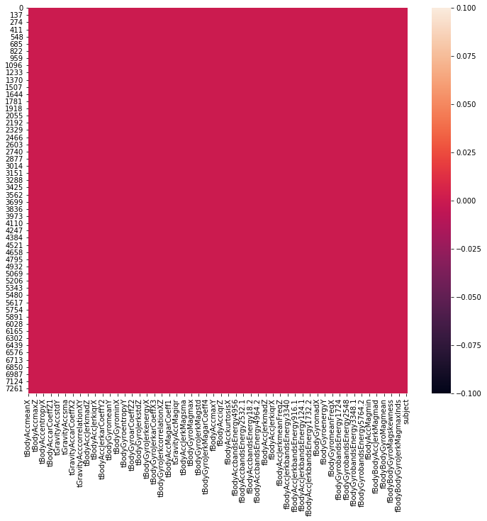

```python
# checking null value using heatmap
plt.figure(figsize=(12,10))
sns.heatmap(data_train.isnull())
```

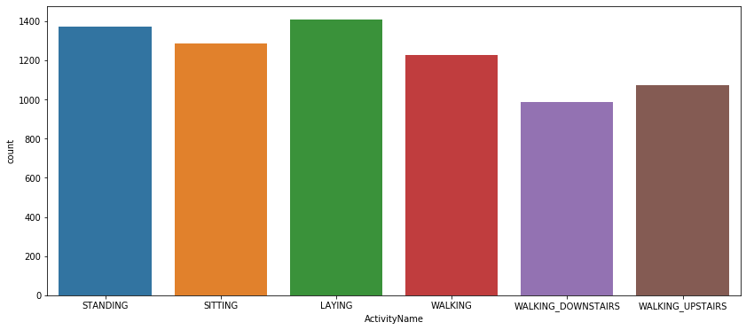

```python
# Visualize the data column name ActivityName
plt.figure(figsize=(14,6))
sns.countplot(data_train['ActivityName'])
```

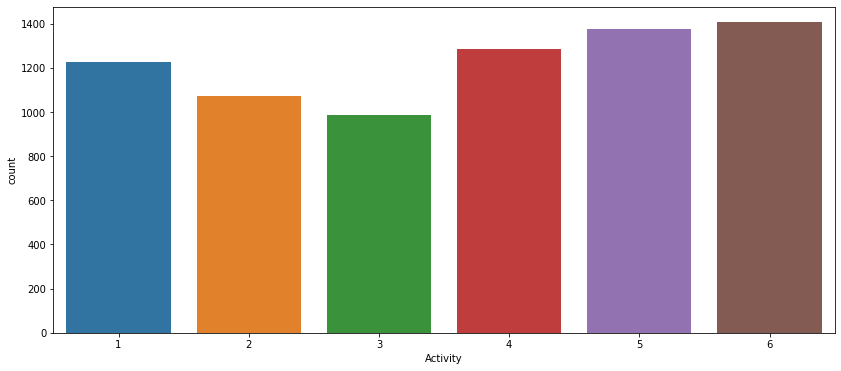

```python
# Visualize the data column name Activity
plt.figure(figsize=(14,6))
sns.countplot(data_train['Activity'])
```

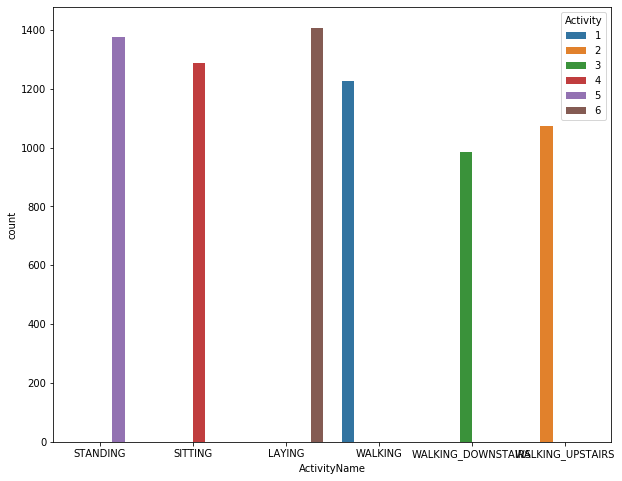

```python
# Visualize comperision between ActivityName And Activity
plt.figure(figsize=(10, 8))
sns.countplot( x = 'ActivityName', hue='Activity', data=data_train)
plt.show()
```

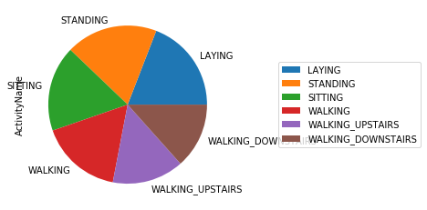

```python
# Plotof ActivityName
data_train.ActivityName.value_counts().plot.pie().legend(loc='center right',bbox_to_anchor=(2,0.5))
```

## Test Data

```python
# Read the test data
data_test=pd.read_csv("test.csv")
data_test.head()
```

|  | tBodyAccmeanX | tBodyAccmeanY | tBodyAccmeanZ | tBodyAccstdX | tBodyAccstdY | tBodyAccstdZ | tBodyAccmadX | tBodyAccmadY | tBodyAccmadZ | tBodyAccmaxX | ... | angletBodyAccMeangravity | angletBodyAccJerkMeangravityMean | angletBodyGyroMeangravityMean | angletBodyGyroJerkMeangravityMean | angleXgravityMean | angleYgravityMean | angleZgravityMean | subject | Activity | ActivityName |
| --- | --- | --- | --- | --- | --- | --- | --- | --- | --- | --- | --- | --- | --- | --- | --- | --- | --- | --- | --- | --- | --- |
| 0 | 0.257178 | -0.023285 | -0.014654 | -0.938404 | -0.920091 | -0.667683 | -0.952501 | -0.925249 | -0.674302 | -0.894088 | ... | 0.006462 | 0.162920 | -0.825886 | 0.271151 | -0.720009 | 0.276801 | -0.057978 | 2 | 5 | STANDING |
| 1 | 0.286027 | -0.013163 | -0.119083 | -0.975415 | -0.967458 | -0.944958 | -0.986799 | -0.968401 | -0.945823 | -0.894088 | ... | -0.083495 | 0.017500 | -0.434375 | 0.920593 | -0.698091 | 0.281343 | -0.083898 | 2 | 5 | STANDING |
| 2 | 0.275485 | -0.026050 | -0.118152 | -0.993819 | -0.969926 | -0.962748 | -0.994403 | -0.970735 | -0.963483 | -0.939260 | ... | -0.034956 | 0.202302 | 0.064103 | 0.145068 | -0.702771 | 0.280083 | -0.079346 | 2 | 5 | STANDING |
| 3 | 0.270298 | -0.032614 | -0.117520 | -0.994743 | -0.973268 | -0.967091 | -0.995274 | -0.974471 | -0.968897 | -0.938610 | ... | -0.017067 | 0.154438 | 0.340134 | 0.296407 | -0.698954 | 0.284114 | -0.077108 | 2 | 5 | STANDING |
| 4 | 0.274833 | -0.027848 | -0.129527 | -0.993852 | -0.967445 | -0.978295 | -0.994111 | -0.965953 | -0.977346 | -0.938610 | ... | -0.002223 | -0.040046 | 0.736715 | -0.118545 | -0.692245 | 0.290722 | -0.073857 | 2 | 5 | STANDING |

5 rows × 564 columns

```python
# Read the shape of test data
data_test.shape
```

```
(2947, 564)
```

```python
# count the value of test data name columns Activity
data_test["Activity"].value_counts()
```

```
6    537
5    532
1    496
4    491
2    471
3    420
Name: Activity, dtype: int64
```

```python
# count the value of test data name columns ActivityName
data_test['ActivityName'].value_counts()
```

```
LAYING                537
STANDING              532
WALKING               496
SITTING               491
WALKING_UPSTAIRS      471
WALKING_DOWNSTAIRS    420
Name: ActivityName, dtype: int64
```

```python
# checking null value in test data
data_test.isnull().sum()
```

```
tBodyAccmeanX        0
tBodyAccmeanY        0
tBodyAccmeanZ        0
tBodyAccstdX         0
tBodyAccstdY         0
                    ..
angleYgravityMean    0
angleZgravityMean    0
subject              0
Activity             0
ActivityName         0
Length: 564, dtype: int64
```

### Visulation on Test data

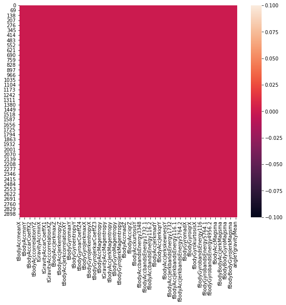

```python
# cheking null value using heatmap
plt.figure(figsize=(10,8))
sns.heatmap(data_test.isnull())
```

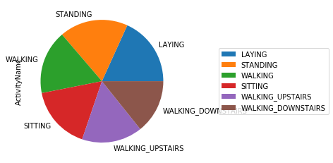

```python
# Plotof ActivityName in test data
data_test.ActivityName.value_counts().plot.pie().legend(loc='center right',bbox_to_anchor=(2,0.5))
```

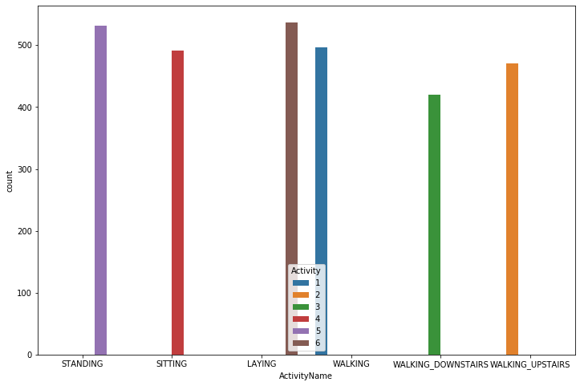

```python
# comparing the ActivityName and Activity in Test data
plt.figure(figsize=(12, 8))
sns.countplot( x = 'ActivityName', hue='Activity', data=data_test)
plt.show()
```

### First take input and output data in Train data

- we droped 'ActivityName' column as Target

```python
X_train = data_train.drop(['subject', 'Activity', 'ActivityName'], axis=1) # input for Train data
y_train = data_train.ActivityName   # target for Train data
```

### Take input and output data in Test data¶

- we droped 'ActivityName' column as Target

```python
X_test = data_test.drop(['subject', 'Activity', 'ActivityName'], axis=1) # input for Test data
y_test = data_test.ActivityName   ## target for Test data
```

## Applying Models :

### Logistic Regression Model :

```python
# Fit the Train data on Logistic Regression Model
from sklearn.linear_model import LogisticRegression

lr = LogisticRegression()
lr.fit(X_train,y_train)
```

```
LogisticRegression()
```

```python
#predict train data
pred=lr.predict(X_train)
```

```python
# check accuracy for train data
from sklearn.metrics import accuracy_score
log_reg= accuracy_score(pred,y_train)
log_reg
```

```
0.9910228509249184
```

```python
# predict Test data
test_pred=lr.predict(X_test)
```

```python
# check accuracy for Test data
Test_log_reg=accuracy_score(test_pred,y_test)
Test_log_reg
```

```
0.8578215134034611
```

### Random Forest Classifier Model :

```python
from sklearn.ensemble import RandomForestClassifier

rfc = RandomForestClassifier()
rfc.fit(X_train,y_train)

pred = rfc.predict(X_train)
# accuracy for Train data
rfc_score = accuracy_score(pred, y_train)
rfc_score
```

```
1.0
```

```python
# checking Accuracy for Test data
test_pred=rfc.predict(X_test)
test_rfc_score=accuracy_score(test_pred,y_test)
test_rfc_score
```

```
0.9273837801153716
```

### K-Nearest Neighbours Model

```python
from sklearn.neighbors import KNeighborsClassifier

knn = KNeighborsClassifier()
knn.fit(X_train, y_train)

pred = knn.predict(X_train)
# accuracy for Train data
knn_score = accuracy_score(pred,y_train)
knn_score
```

```
0.984221980413493
```

```python
# checking Accuracy for Test data
test_pred=knn.predict(X_test)
test_knn_score=accuracy_score(test_pred,y_test)
test_knn_score
```

```
0.9002375296912114
```

### Decision Tree Classifier Model :

```python
from sklearn.tree import DecisionTreeClassifier

dtc = DecisionTreeClassifier()
dtc.fit(X_train, y_train)

pred = dtc.predict(X_train)
# accuracy for Train data
dtc_score = accuracy_score(pred,y_train)
dtc_score
```

```
1.0
```

```python
# checking Accuracy for Test data
test_pred=dtc.predict(X_test)
test_dtc_score=accuracy_score(test_pred,y_test)
test_dtc_score
```

```
0.8578215134034611
```

### Conclusion :

```python
fin_res = {'Models' : ['Logistic Regression', 'K-Nearest Neighbours', 'Decision Tree Classifier', 'Random Forest Classifier'],
'Train_Acc_Score': [log_reg, knn_score, dtc_score, rfc_score],
           'Test_Acc_Score':[Test_log_reg,test_knn_score,test_dtc_score,test_rfc_score]}

nums=[1, 2, 3, 4]

conclusion = pd.DataFrame(fin_res, index=nums)
conclusion
```

|  | Models | Train_Acc_Score | Test_Acc_Score |
| --- | --- | --- | --- |
| 1 | Logistic Regression | 0.991023 | 0.857822 |
| 2 | K-Nearest Neighbours | 0.984222 | 0.900238 |
| 3 | Decision Tree Classifier | 1.000000 | 0.857822 |
| 4 | Random Forest Classifier | 1.000000 | 0.927384 |

### we find the good model Random Forest Classifier for this data